# Praca Domowa nr.2

Witold Merkel

W katalogu PD1 znalazłem następujący wykres zrobiony za podstawie artykułu: “http://wyborcza.pl/1,75398,19061937,tns-dla-wyborczej-w-nowym-sejmie-trzy-czy-siedem-partii.html”.

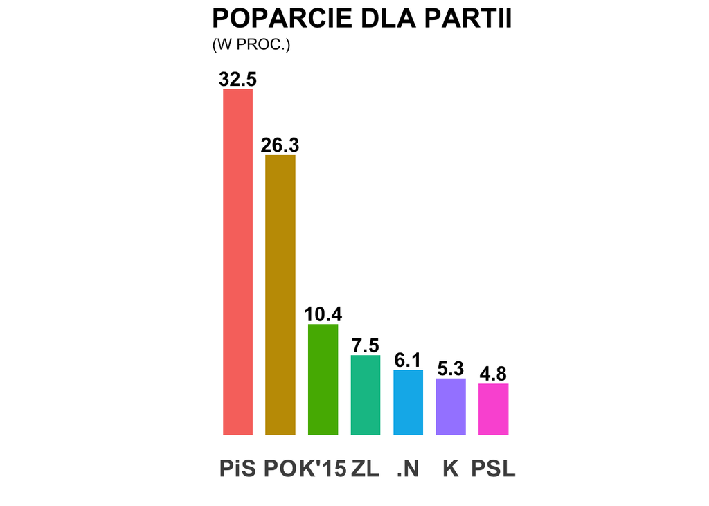

Na powyższym wykresie nie ma osi, nie jest to specjalnie złe, ale uważam, że czytelniej jest z nimi. Dzięki nim łatwiej jest nam zwyzualizować sytuację. Wykres nie zawiera legendy, przez to istnieje możliwość, że niektórzy ludzie nie będą w stanie rozszyfrować wszystkich skrótów.

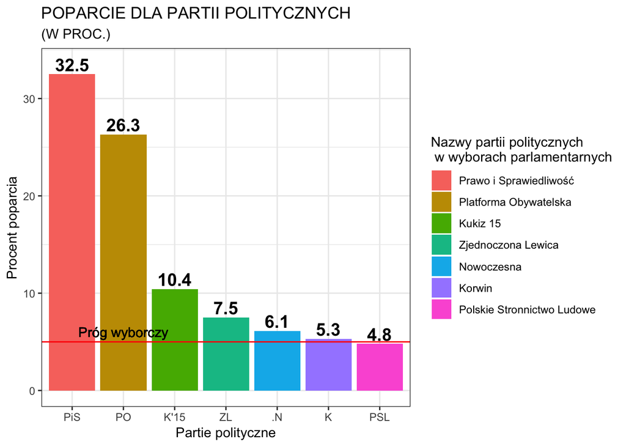

Na moim wykresie umieściłem legendę, która wyjaśnia skróty partii politycznych, będzię to przydatnę dla ludzi, którzy nie orientują się w świecie nazw, ale dalej chcieliby wiedzieć kto jakie ma poparcie. Podpisałem obydwie osię, żeby nie było żadnych nieporozumień albo jakichkolwiek pomówień. Dodatkowo wprowadziłem, poziomą linię na poziomie 5 procent, jest to próg wyborczy, jeżeli jakaś partia go nie przekroczy to nie dostanie się do sejmu. Uważam, że jest to ciekawa informacja i wiele osób może nie zdawać sobie sprawy z istnienia takiego przepisu, więc jest to ulepszenie. Umieściłem również tło w kratkę i “zamknąłem” w kwadracie przez co jest łatwiej skupić się na danych, można też dzięki kratce łatwiej porównać wysokość słupków, dla tych ludzi którzy potrzebują wizualizacji.